# Project 1

Author

Justin Cornejo Leon

```r
library(tidyverse)
library(rpart)
library(randomForest)
library(vip)
library(ggplot2)
```

```r
library(AppliedPredictiveModeling)
data("abalone")
```

## Part 1: Exploratory Data Analysis

```r
summary(abalone)
```

```
 Type      LongestShell      Diameter          Height        WholeWeight
 F:1307   Min.   :0.075   Min.   :0.0550   Min.   :0.0000   Min.   :0.0020
 I:1342   1st Qu.:0.450   1st Qu.:0.3500   1st Qu.:0.1150   1st Qu.:0.4415
 M:1528   Median :0.545   Median :0.4250   Median :0.1400   Median :0.7995
          Mean   :0.524   Mean   :0.4079   Mean   :0.1395   Mean   :0.8287
          3rd Qu.:0.615   3rd Qu.:0.4800   3rd Qu.:0.1650   3rd Qu.:1.1530
          Max.   :0.815   Max.   :0.6500   Max.   :1.1300   Max.   :2.8255
 ShuckedWeight    VisceraWeight     ShellWeight         Rings
 Min.   :0.0010   Min.   :0.0005   Min.   :0.0015   Min.   : 1.000
 1st Qu.:0.1860   1st Qu.:0.0935   1st Qu.:0.1300   1st Qu.: 8.000
 Median :0.3360   Median :0.1710   Median :0.2340   Median : 9.000
 Mean   :0.3594   Mean   :0.1806   Mean   :0.2388   Mean   : 9.934
 3rd Qu.:0.5020   3rd Qu.:0.2530   3rd Qu.:0.3290   3rd Qu.:11.000
 Max.   :1.4880   Max.   :0.7600   Max.   :1.0050   Max.   :29.000
```

```r
head(abalone)
```

```
  Type LongestShell Diameter Height WholeWeight ShuckedWeight VisceraWeight
1    M        0.455    0.365  0.095      0.5140        0.2245        0.1010
2    M        0.350    0.265  0.090      0.2255        0.0995        0.0485
3    F        0.530    0.420  0.135      0.6770        0.2565        0.1415
4    M        0.440    0.365  0.125      0.5160        0.2155        0.1140
5    I        0.330    0.255  0.080      0.2050        0.0895        0.0395
6    I        0.425    0.300  0.095      0.3515        0.1410        0.0775
  ShellWeight Rings
1       0.150    15
2       0.070     7
3       0.210     9
4       0.155    10
5       0.055     7
6       0.120     8
```

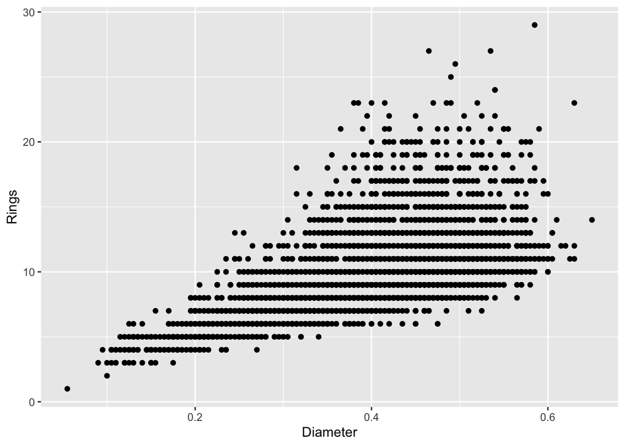

```r
ggplot(abalone, aes(x = Diameter, y = Rings)) +
  geom_point() +
  labs(x = "Diameter", y = "Rings")
```

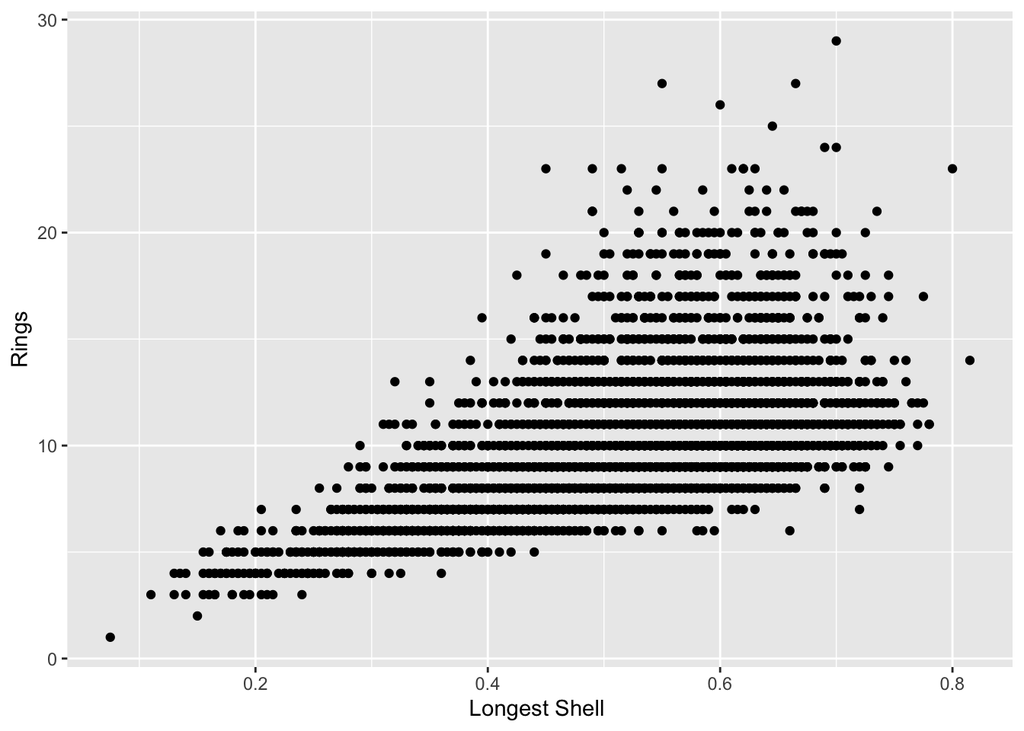

```r
ggplot(abalone, aes(x = LongestShell, y = Rings)) +
  geom_point() +
  labs(x = "Longest Shell ", y = "Rings")
```

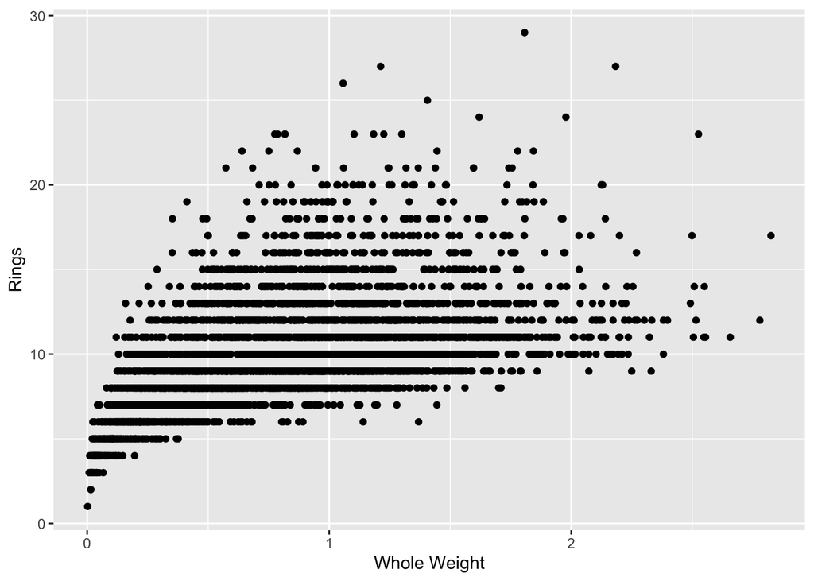

```r
ggplot(abalone, aes(x = WholeWeight, y = Rings)) +
  geom_point() +
  labs(x = "Whole Weight", y = "Rings")
```

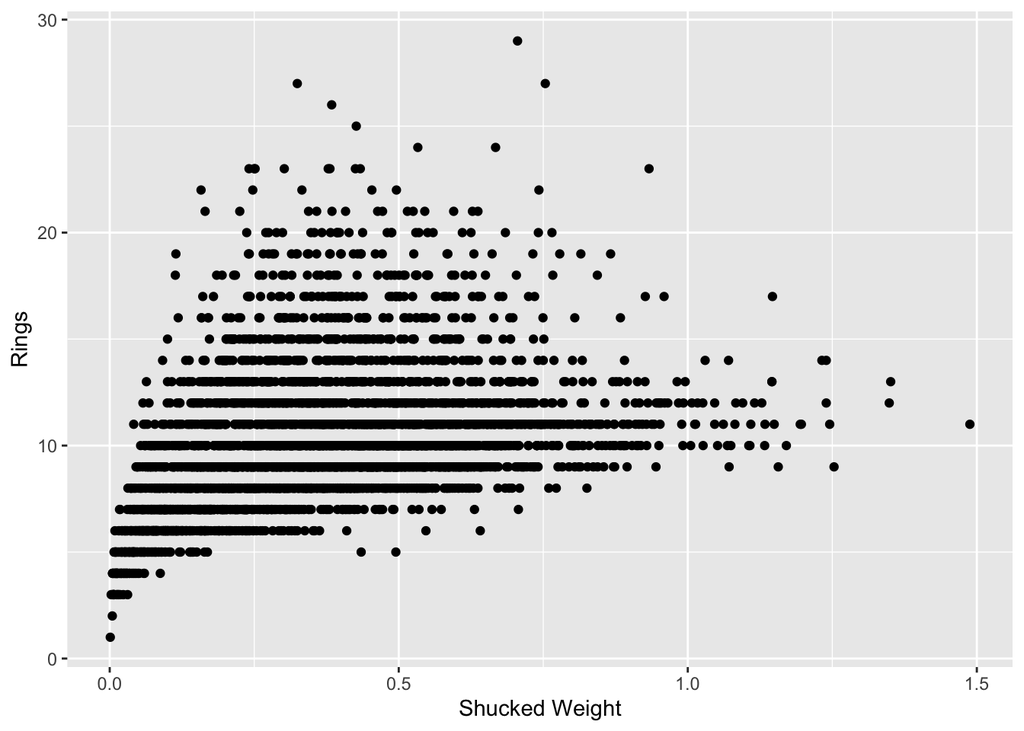

```r
ggplot(abalone, aes(x = ShuckedWeight, y = Rings)) +
  geom_point() +
  labs(x = "Shucked Weight", y = "Rings")
```

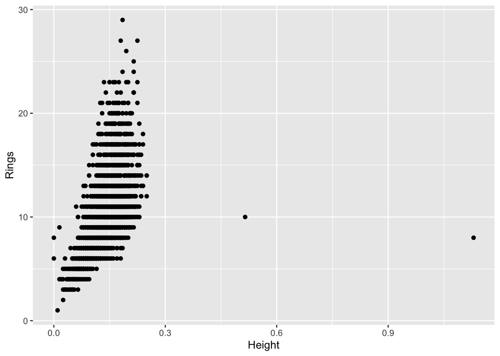

```r
ggplot(abalone, aes(x = Height, y = Rings)) +
  geom_point() +
  labs(x = "Height", y = "Rings")
```

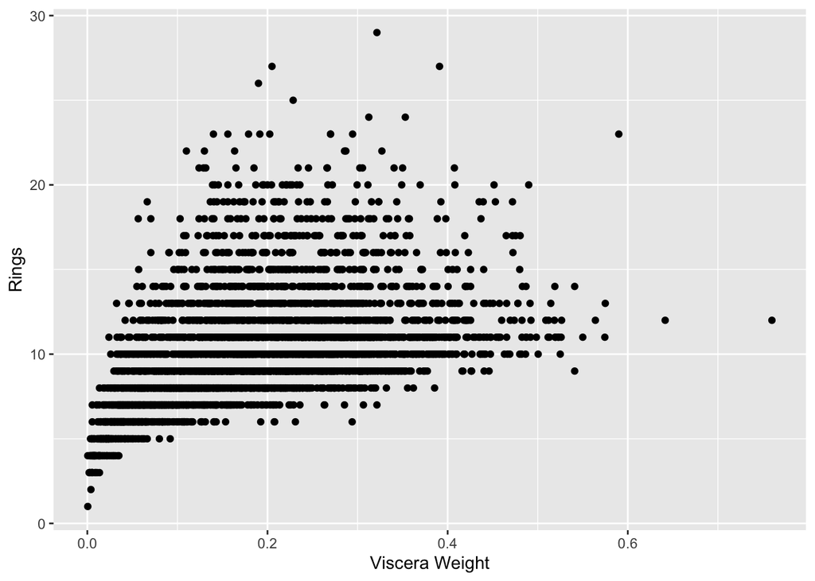

```r
ggplot(abalone, aes(x = VisceraWeight, y = Rings)) +
  geom_point() +
  labs(x = "Viscera Weight", y = "Rings")
```

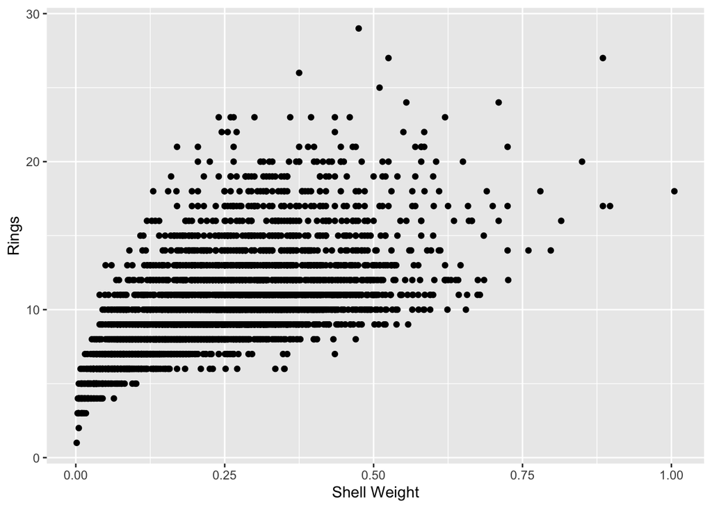

```r
ggplot(abalone, aes(x = ShellWeight, y = Rings)) +
  geom_point() +
  labs(x = "Shell Weight", y = "Rings")
```

I first noticed one of the scatter plots is not similar to the others which is the scatterplot for height. The points on this plot seemed to be more condesed with a few outliers. All of the other scatter plots seem to have a pattern with how they spread the data. The grpahs that are related such as weight whether it be viscera, shell, whole, and shucked have the same spread but differ soemwhat. The same could be said for the graphs related to shape.

## Part 2: Cross Validation

### a

```r
set.seed(123)
n <- nrow(abalone)
train_indices <- sample(1:n, floor(0.7 * n), replace = FALSE)

train_data <- abalone[train_indices, ]
test_data <- abalone[-train_indices, ]
```

### b

```r
lm1 <- lm(Rings ~ LongestShell + Diameter + Height + WholeWeight + ShuckedWeight + VisceraWeight + ShellWeight,
               data = train_data)
summary(lm1)
```

```
Call:
lm(formula = Rings ~ LongestShell + Diameter + Height + WholeWeight +
    ShuckedWeight + VisceraWeight + ShellWeight, data = train_data)

Residuals:
    Min      1Q  Median      3Q     Max
-8.1424 -1.3632 -0.3731  0.9248 13.9292

Coefficients:
              Estimate Std. Error t value Pr(>|t|)
(Intercept)     2.2708     0.3209   7.076 1.85e-12 ***
LongestShell   -1.6970     2.1453  -0.791    0.429
Diameter       11.6500     2.6540   4.390 1.18e-05 ***
Height         26.9167     2.7666   9.729  < 2e-16 ***
WholeWeight     9.3378     0.8730  10.696  < 2e-16 ***
ShuckedWeight -20.2783     0.9972 -20.336  < 2e-16 ***
VisceraWeight -11.2379     1.5776  -7.123 1.32e-12 ***
ShellWeight     6.8092     1.3351   5.100 3.61e-07 ***
---
Signif. codes:  0 '***' 0.001 '**' 0.01 '*' 0.05 '.' 0.1 ' ' 1

Residual standard error: 2.207 on 2915 degrees of freedom
Multiple R-squared:  0.5354,    Adjusted R-squared:  0.5343
F-statistic: 479.8 on 7 and 2915 DF,  p-value: < 2.2e-16
```

### c

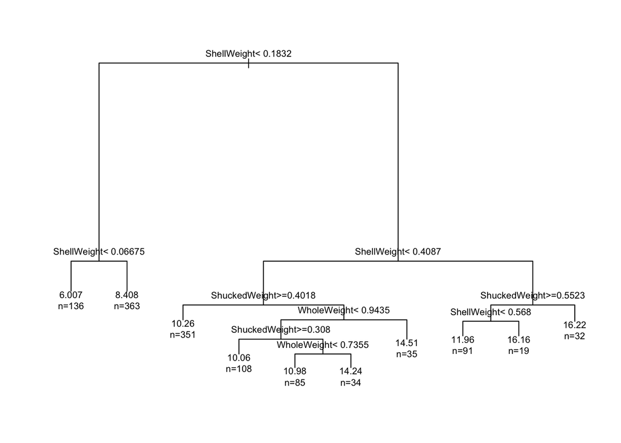

```r
t1 <- rpart( Rings ~ LongestShell + Diameter + Height + WholeWeight + ShuckedWeight + VisceraWeight + ShellWeight, data = test_data )

par(cex=0.7, xpd=NA)
plot(t1)
text(t1, use.n = TRUE, cex = 0.9)
```

### d

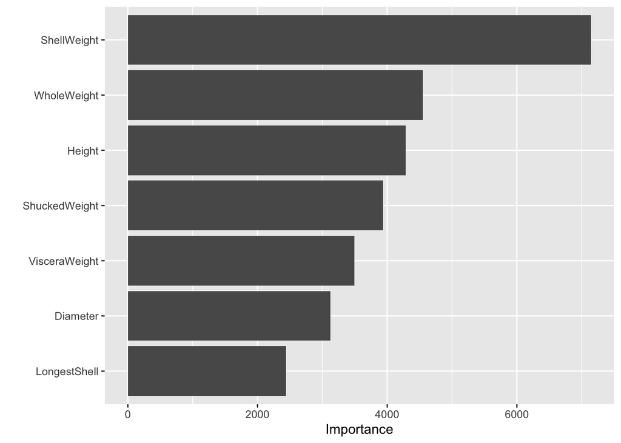

```r
rf_1 <- randomForest(Rings ~ LongestShell + Diameter + Height + WholeWeight + ShuckedWeight + VisceraWeight + ShellWeight, data = train_data)

vip(rf_1, num_features = 7)
```

### e

```r
RMSE <- function(y, y_hat) {
  sqrt(mean((y - y_hat)^2))
}
```

```r
pred_rf <- predict(rf_1, newdata = test_data)
tree_predictions <- predict(t1, newdata = test_data)
pred_lm <- predict(lm1, newdata = test_data)
```

```r
RMSE(test_data$Rings, pred_rf)
```

```
[1] 2.118112
```

```r
RMSE(test_data$Rings, tree_predictions)
```

```
[1] 2.194621
```

```r
RMSE(test_data$Rings, pred_lm)
```

```
[1] 2.325949
```

The results for the cross validation test are very similar but the random forest prediction seems to have the best results when comparing all three. We want a lower RSME as it can indicate when a model is accurate to the actual results. The model with the worst predictive performannce would be the linear model prediction which means the model might not be as good when it comes to predicting underlying patterns and predictions in the data set.

### f

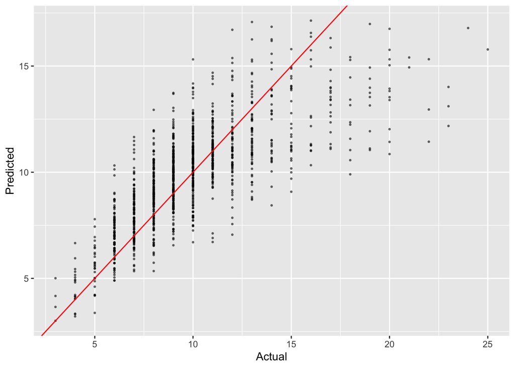

```r
pred_df <- data.frame(
  Actual = test_data$Rings,
  Predicted = pred_rf
)

ggplot(pred_df, aes(x = Actual, y = Predicted)) +
  geom_point(size = 0.5, alpha = 0.5) +
  geom_abline(intercept = 0, slope = 1, color = "red")
```

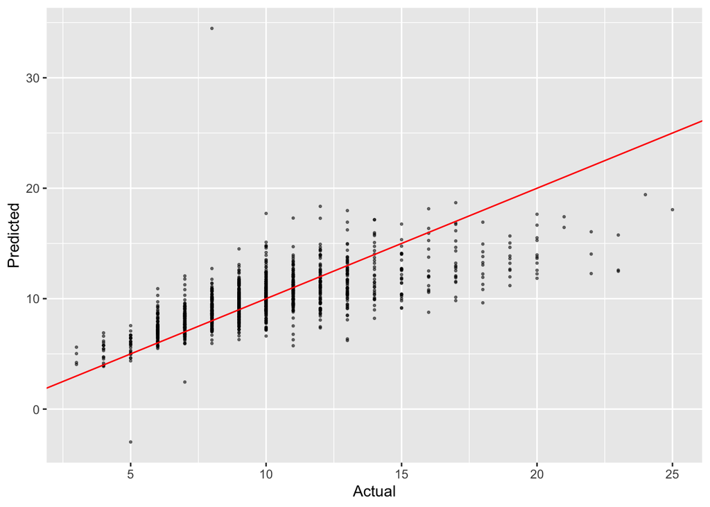

```r
pred_df <- data.frame(
  Actual = test_data$Rings,
  Predicted = pred_lm # makes predictions using OOB data
)

ggplot(pred_df, aes(x = Actual, y = Predicted)) +
  geom_point(size = 0.5, alpha = 0.5) +
  geom_abline(intercept = 0, slope = 1, color = "red")
```

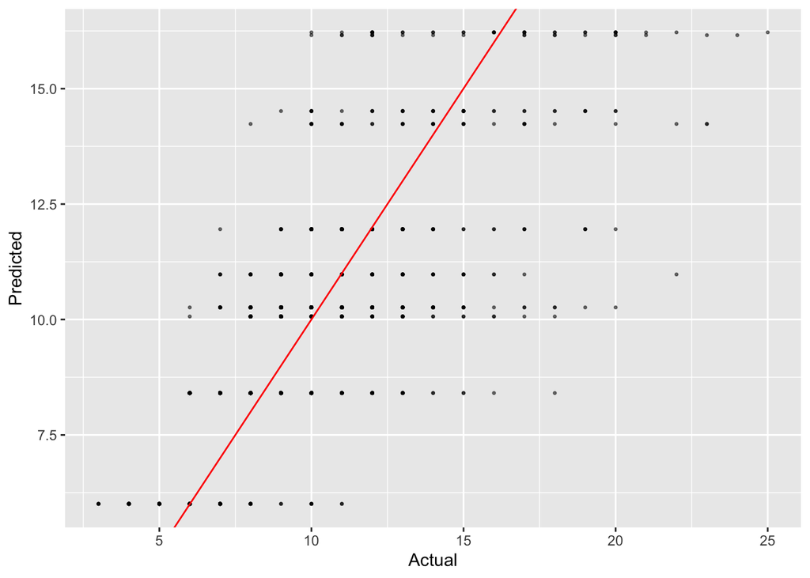

```r
pred_df <- data.frame(
  Actual = test_data$Rings,
  Predicted = tree_predictions # makes predictions using OOB data
)

ggplot(pred_df, aes(x = Actual, y = Predicted)) +
  geom_point(size = 0.5, alpha = 0.5) +
  geom_abline(intercept = 0, slope = 1, color = "red")
```

The regression tree in this data set stands out compared to the other two. This might be due to how the regression tree formula partitions the data. A regression tree uses different regions to compare the data and this is prevelant especailly in data sets with much more data. This is what I think ultimatley gives the graph a step-like pattern.